# Data analysis of embryotoxicity (mortality and development delay)

#### 24 hours

Shapiro’s test for testing normality.

```r
result.shapiro<-shapiro.test(gmiaguaporo$`24 h`)
if (result.shapiro$p.value > 0.05){
  print('normal distribution')
} else {
  print('non-normal distribution')
}
```

```
## [1] "non-normal distribution"
```

Since the data does not have a normal distribution, then we applied a non parametric test (Kruskal’s test).

```r
result.kruskal<-kruskal.test(gmiaguaporo$'24 h'~gmiaguaporo$Punto, data=gmiaguaporo)
if (result.kruskal$p.value > 0.05){
  print('no significant differences')
} else {
  print('significant differences')
}
```

```
## [1] "significant differences"
```

We obtain significant differences between the mortality at different sediment concentrations. So, we apply a post hoc test (Dunn’s test).

```r
gmiaguaporo[,"Punto"] <- lapply(gmiaguaporo[, "Punto"], as.factor)
dunnTest(gmiaguaporo$'24 h'~gmiaguaporo$Punto,data = gmiaguaporo,method='none')
```

```
## Dunn (1964) Kruskal-Wallis multiple comparison
```

```
##   with no adjustment for p-values.
```

```
##    Comparison        Z      P.unadj        P.adj
## 1      C - P1 3.521204 0.0004295913 0.0004295913
## 2      C - P2 3.521204 0.0004295913 0.0004295913
## 3     P1 - P2 0.000000 1.0000000000 1.0000000000
## 4      C - P3 3.521204 0.0004295913 0.0004295913
## 5     P1 - P3 0.000000 1.0000000000 1.0000000000
## 6     P2 - P3 0.000000 1.0000000000 1.0000000000
## 7      C - P4 3.521204 0.0004295913 0.0004295913
## 8     P1 - P4 0.000000 1.0000000000 1.0000000000
## 9     P2 - P4 0.000000 1.0000000000 1.0000000000
## 10    P3 - P4 0.000000 1.0000000000 1.0000000000
```

#### 48 hours

Shapiro’s test for testing normality.

```r
result.shapiro<-shapiro.test(gmiaguaporo$`48 h`)
if (result.shapiro$p.value > 0.05){
  print('normal distribution')
} else {
  print('non-normal distribution')
}
```

```
## [1] "non-normal distribution"
```

Since the data does not have a normal distribution, then we applied a non parametric test (Kruskal’s test).

```r
result.kruskal<-kruskal.test(gmiaguaporo$'48 h'~gmiaguaporo$Punto, data=gmiaguaporo)
if (result.kruskal$p.value > 0.05){
  print('no significant differences')
} else {
  print('significant differences')
}
```

```
## [1] "no significant differences"
```

We did not obtain significant differences between the mortality at different sediment concentrations.

#### 72 hours

Shapiro’s test for testing normality.

```r
result.shapiro<-shapiro.test(gmiaguaporo$`72 h`)
if (result.shapiro$p.value > 0.05){
  print('normal distribution')
} else {
  print('non-normal distribution')
}
```

```
## [1] "non-normal distribution"
```

Since the data does not have a normal distribution, then we applied a non parametric test (Kruskal’s test).

```r
result.kruskal<-kruskal.test(gmiaguaporo$'72 h'~gmiaguaporo$Punto, data=gmiaguaporo)
if (result.kruskal$p.value > 0.05){
  print('no significant differences')
} else {
  print('significant differences')
}
```

```
## [1] "no significant differences"
```

We do not obtain significant differences between the mortality at different sediment concentrations.

#### 96 hours

Shapiro’s test for testing normality.

```r
result.shapiro<-shapiro.test(gmiaguaporo$`96 h`)
if (result.shapiro$p.value > 0.05){
  print('normal distribution')
} else {
  print('non-normal distribution')
}
```

```
## [1] "non-normal distribution"
```

Since the data does not have a normal distribution, then we applied a non parametric test (Kruskal’s test).

```r
result.kruskal<-kruskal.test(gmiaguaporo$'96 h'~gmiaguaporo$Punto, data=gmiaguaporo)
if (result.kruskal$p.value > 0.05){
  print('no significant differences')
} else {
  print('significant differences')
}
```

```
## [1] "significant differences"
```

We obtain significant differences between the mortality at different sediment concentrations. So, we apply a post hoc test (Dunn’s test).

```r
gmiaguaporo[,"Punto"] <- lapply(gmiaguaporo[, "Punto"], as.factor)
dunnTest(gmiaguaporo$'96 h'~gmiaguaporo$Punto,data = gmiaguaporo,method='none')
```

```
## Dunn (1964) Kruskal-Wallis multiple comparison
```

```
##   with no adjustment for p-values.
```

```
##    Comparison            Z      P.unadj        P.adj
## 1      C - P1  4.534303757 5.779381e-06 5.779381e-06
## 2      C - P2  5.404271223 6.507242e-08 6.507242e-08
## 3     P1 - P2  0.869967466 3.843182e-01 3.843182e-01
## 4      C - P3  5.100794200 3.382312e-07 3.382312e-07
## 5     P1 - P3  0.566490443 5.710604e-01 5.710604e-01
## 6     P2 - P3 -0.303477023 7.615264e-01 7.615264e-01
## 7      C - P4  5.103174412 3.340029e-07 3.340029e-07
## 8     P1 - P4  0.568870655 5.694439e-01 5.694439e-01
## 9     P2 - P4 -0.301096811 7.633407e-01 7.633407e-01
## 10    P3 - P4  0.002380212 9.981009e-01 9.981009e-01
```

## Differences between sediment and pore water at different times

Loading the data needed for estimating differences between the GMI in sediment and pore water.

```r
gmiaguaporo$Punto=paste0(gmiaguaporo$Punto," Agua poro")
gmisedimento$Punto=paste0(gmisedimento$Punto," Sedimento")
gmi_agua_sed<-merge.data.frame(gmiaguaporo,gmisedimento, all.x=TRUE,all.y=TRUE)
```

```r
gmi_agua_sed_T<-gmi_agua_sed[1:120,]
gmi_agua_sed_P1<-gmi_agua_sed[121:240,]
gmi_agua_sed_P2<-gmi_agua_sed[241:360,]
gmi_agua_sed_P3<-gmi_agua_sed[361:480,]
gmi_agua_sed_P4<-gmi_agua_sed[481:600,]
```

### P1

#### 12 hours

Shapiro’s test for testing normality.

```r
result.shapiro<-shapiro.test(gmi_agua_sed_P1$`12 h`)
if (result.shapiro$p.value > 0.05){
  print('normal distribution')
} else {
  print('non-normal distribution')
}
```

```
## [1] "non-normal distribution"
```

```r
result.wilcox<-wilcox.test(gmi_agua_sed_P1$'12 h'~gmi_agua_sed_P1$Punto, data=gmi_agua_sed_P1)
if (result.wilcox$p.value > 0.05){
  print('no significant differences')
} else {
  print('significant differences')
}
```

```
## [1] "significant differences"
```

```r
result.wilcox$p.value
```

```
## [1] 1.36241e-07
```

#### 24 hours

Shapiro’s test for testing normality.

```r
result.shapiro<-shapiro.test(gmi_agua_sed_P1$`24 h`)
if (result.shapiro$p.value > 0.05){
  print('normal distribution')
} else {
  print('non-normal distribution')
}
```

```
## [1] "non-normal distribution"
```

Since the data does not have a normal distribution, then we applied a non parametric test (Mann-Whitney test).

```r
result.wilcox<-wilcox.test(gmi_agua_sed_P1$'24 h'~gmi_agua_sed_P1$Punto, data=gmi_agua_sed_P1)
if (result.wilcox$p.value > 0.05){
  print('no significant differences')
} else {
  print('significant differences')
}
```

```
## [1] "no significant differences"
```

```r
result.wilcox$p.value
```

```
## [1] 0.3355347
```

#### 48 hours

Shapiro’s test for testing normality.

```r
result.shapiro<-shapiro.test(gmi_agua_sed_P1$`48 h`)
if (result.shapiro$p.value > 0.05){
  print('normal distribution')
} else {
  print('non-normal distribution')
}
```

```
## [1] "non-normal distribution"
```

Since the data does not have a normal distribution, then we applied a non parametric test (Mann-Whitney test).

```r
result.wilcox<-wilcox.test(gmi_agua_sed_P1$'48 h'~gmi_agua_sed_P1$Punto, data=gmi_agua_sed_P1)
if (result.wilcox$p.value > 0.05){
  print('no significant differences')
} else {
  print('significant differences')
}
```

```
## [1] "significant differences"
```

```r
result.wilcox$p.value
```

```
## [1] 0.0001674603
```

#### 72 hours

Shapiro’s test for testing normality.

```r
result.shapiro<-shapiro.test(gmi_agua_sed_P1$`72 h`)
if (result.shapiro$p.value > 0.05){
  print('normal distribution')
} else {
  print('non-normal distribution')
}
```

```
## [1] "non-normal distribution"
```

Since the data does not have a normal distribution, then we applied a non parametric test (Mann-Whitney test).

```r
result.wilcox<-wilcox.test(gmi_agua_sed_P1$'72 h'~gmi_agua_sed_P1$Punto, data=gmi_agua_sed_P1)
if (result.wilcox$p.value > 0.05){
  print('no significant differences')
} else {
  print('significant differences')
}
```

```
## [1] "significant differences"
```

```r
result.wilcox$p.value
```

```
## [1] 2.125575e-07
```

#### 96 hours

Shapiro’s test for testing normality.

```r
result.shapiro<-shapiro.test(gmi_agua_sed_P1$`96 h`)
if (result.shapiro$p.value > 0.05){
  print('normal distribution')
} else {
  print('non-normal distribution')
}
```

```
## [1] "non-normal distribution"
```

Since the data does not have a normal distribution, then we applied a non parametric test (Mann-Whitney test).

```r
result.wilcox<-wilcox.test(gmi_agua_sed_P1$'96 h'~gmi_agua_sed_P1$Punto, data=gmi_agua_sed_P1)
if (result.wilcox$p.value > 0.05){
  print('no significant differences')
} else {
  print('significant differences')
}
```

```
## [1] "significant differences"
```

```r
result.wilcox$p.value
```

```
## [1] 8.196349e-07
```

### P2

#### 12 hours

Shapiro’s test for testing normality.

```r
result.shapiro<-shapiro.test(gmi_agua_sed_P2$`12 h`)
if (result.shapiro$p.value > 0.05){
  print('normal distribution')
} else {
  print('non-normal distribution')
}
```

```
## [1] "non-normal distribution"
```

Since the data does not have a normal distribution, then we applied a non parametric test (Mann-Whitney test).

```r
result.wilcox<-wilcox.test(gmi_agua_sed_P2$'12 h'~gmi_agua_sed_P2$Punto, data=gmi_agua_sed_P2)
if (result.wilcox$p.value > 0.05){
  print('no significant differences')
} else {
  print('significant differences')
}
```

```
## [1] "significant differences"
```

```r
result.wilcox$p.value
```

```
## [1] 8.143586e-05
```

#### 24 hours

Shapiro’s test for testing normality.

```r
result.shapiro<-shapiro.test(gmi_agua_sed_P2$`24 h`)
if (result.shapiro$p.value > 0.05){
  print('normal distribution')
} else {
  print('non-normal distribution')
}
```

```
## [1] "non-normal distribution"
```

Since the data does not have a normal distribution, then we applied a non parametric test (Mann-Whitney test).

```r
result.wilcox<-wilcox.test(gmi_agua_sed_P2$'24 h'~gmi_agua_sed_P2$Punto, data=gmi_agua_sed_P2)
if (result.wilcox$p.value > 0.05){
  print('no significant differences')
} else {
  print('significant differences')
}
```

```
## [1] "significant differences"
```

```r
result.wilcox$p.value
```

```
## [1] 6.198006e-10
```

#### 48 hours

Shapiro’s test for testing normality.

```r
result.shapiro<-shapiro.test(gmi_agua_sed_P2$`48 h`)
if (result.shapiro$p.value > 0.05){
  print('normal distribution')
} else {
  print('non-normal distribution')
}
```

```
## [1] "non-normal distribution"
```

Since the data does not have a normal distribution, then we applied a non parametric test (Mann-Whitney test).

```r
result.wilcox<-wilcox.test(gmi_agua_sed_P2$'48 h'~gmi_agua_sed_P2$Punto, data=gmi_agua_sed_P2)
if (result.wilcox$p.value > 0.05){
  print('no significant differences')
} else {
  print('significant differences')
}
```

```
## [1] "significant differences"
```

```r
result.wilcox$p.value
```

```
## [1] 0.002940534
```

#### 72 hours

Shapiro’s test for testing normality.

```r
result.shapiro<-shapiro.test(gmi_agua_sed_P2$`72 h`)
if (result.shapiro$p.value > 0.05){
  print('normal distribution')
} else {
  print('non-normal distribution')
}
```

```
## [1] "non-normal distribution"
```

Since the data does not have a normal distribution, then we applied a non parametric test (Mann-Whitney test).

```r
result.wilcox<-wilcox.test(gmi_agua_sed_P2$'72 h'~gmi_agua_sed_P2$Punto, data=gmi_agua_sed_P2)
if (result.wilcox$p.value > 0.05){
  print('no significant differences')
} else {
  print('significant differences')
}
```

```
## [1] "no significant differences"
```

```r
result.wilcox$p.value
```

```
## [1] 0.4095597
```

#### 96 hours

Shapiro’s test for testing normality.

```r
result.shapiro<-shapiro.test(gmi_agua_sed_P2$`96 h`)
if (result.shapiro$p.value > 0.05){
  print('normal distribution')
} else {
  print('non-normal distribution')
}
```

```
## [1] "non-normal distribution"
```

Since the data does not have a normal distribution, then we applied a non parametric test (Mann-Whitney test).

```r
result.wilcox<-wilcox.test(gmi_agua_sed_P2$'96 h'~gmi_agua_sed_P2$Punto, data=gmi_agua_sed_P2)
if (result.wilcox$p.value > 0.05){
  print('no significant differences')
} else {
  print('significant differences')
}
```

```
## [1] "no significant differences"
```

```r
result.wilcox$p.value
```

```
## [1] 0.3296899
```

### P3

#### 12 hours

Shapiro’s test for testing normality.

```r
result.shapiro<-shapiro.test(gmi_agua_sed_P3$`12 h`)
if (result.shapiro$p.value > 0.05){
  print('normal distribution')
} else {
  print('non-normal distribution')
}
```

```
## [1] "non-normal distribution"
```

Since the data does not have a normal distribution, then we applied a non parametric test (Mann-Whitney test).

```r
result.wilcox<-wilcox.test(gmi_agua_sed_P3$'12 h'~gmi_agua_sed_P3$Punto, data=gmi_agua_sed_P3)
if (result.wilcox$p.value > 0.05){
  print('no significant differences')
} else {
  print('significant differences')
}
```

```
## [1] "no significant differences"
```

```r
result.wilcox$p.value
```

```
## [1] 0.363249
```

#### 24 hours

Shapiro’s test for testing normality.

```r
result.shapiro<-shapiro.test(gmi_agua_sed_P3$`24 h`)
if (result.shapiro$p.value > 0.05){
  print('normal distribution')
} else {
  print('non-normal distribution')
}
```

```
## [1] "non-normal distribution"
```

Since the data does not have a normal distribution, then we applied a non parametric test (Mann-Whitney test).

```r
result.wilcox<-wilcox.test(gmi_agua_sed_P3$'24 h'~gmi_agua_sed_P3$Punto, data=gmi_agua_sed_P3)
if (result.wilcox$p.value > 0.05){
  print('no significant differences')
} else {
  print('significant differences')
}
```

```
## [1] "significant differences"
```

```r
result.wilcox$p.value
```

```
## [1] 2.060528e-06
```

#### 48 hours

Shapiro’s test for testing normality.

```r
result.shapiro<-shapiro.test(gmi_agua_sed_P3$`48 h`)
if (result.shapiro$p.value > 0.05){
  print('normal distribution')
} else {
  print('non-normal distribution')
}
```

```
## [1] "non-normal distribution"
```

Since the data does not have a normal distribution, then we applied a non parametric test (Mann-Whitney test).

```r
result.wilcox<-wilcox.test(gmi_agua_sed_P3$'48 h'~gmi_agua_sed_P3$Punto, data=gmi_agua_sed_P3)
if (result.wilcox$p.value > 0.05){
  print('no significant differences')
} else {
  print('significant differences')
}
```

```
## [1] "significant differences"
```

```r
result.wilcox$p.value
```

```
## [1] 0.002217197
```

#### 72 hours

Shapiro’s test for testing normality.

```r
result.shapiro<-shapiro.test(gmi_agua_sed_P3$`72 h`)
if (result.shapiro$p.value > 0.05){
  print('normal distribution')
} else {
  print('non-normal distribution')
}
```

```
## [1] "non-normal distribution"
```

Since the data does not have a normal distribution, then we applied a non parametric test (Mann-Whitney test).

```r
result.wilcox<-wilcox.test(gmi_agua_sed_P3$'72 h'~gmi_agua_sed_P3$Punto, data=gmi_agua_sed_P3)
if (result.wilcox$p.value > 0.05){
  print('no significant differences')
} else {
  print('significant differences')
}
```

```
## [1] "no significant differences"
```

```r
result.wilcox$p.value
```

```
## [1] 0.5989006
```

#### 96 hours

Shapiro’s test for testing normality.

```r
result.shapiro<-shapiro.test(gmi_agua_sed_P3$`96 h`)
if (result.shapiro$p.value > 0.05){
  print('normal distribution')
} else {
  print('non-normal distribution')
}
```

```
## [1] "non-normal distribution"
```

Since the data does not have a normal distribution, then we applied a non parametric test (Mann-Whitney test).

```r
result.wilcox<-wilcox.test(gmi_agua_sed_P3$'96 h'~gmi_agua_sed_P3$Punto, data=gmi_agua_sed_P3)
if (result.wilcox$p.value > 0.05){
  print('no significant differences')
} else {
  print('significant differences')
}
```

```
## [1] "no significant differences"
```

```r
result.wilcox$p.value
```

```
## [1] 0.3944507
```

### P4

#### 12 hours

Shapiro’s test for testing normality.

```r
result.shapiro<-shapiro.test(gmi_agua_sed_P4$`12 h`)
if (result.shapiro$p.value > 0.05){
  print('normal distribution')
} else {
  print('non-normal distribution')
}
```

```
## [1] "non-normal distribution"
```

Since the data does not have a normal distribution, then we applied a non parametric test (Mann-Whitney test).

```r
result.wilcox<-wilcox.test(gmi_agua_sed_P4$'12 h'~gmi_agua_sed_P3$Punto, data=gmi_agua_sed_P3)
if (result.wilcox$p.value > 0.05){
  print('no significant differences')
} else {
  print('significant differences')
}
```

```
## [1] "no significant differences"
```

```r
result.wilcox$p.value
```

```
## [1] 0.1000716
```

#### 24 hours

Shapiro’s test for testing normality.

```r
result.shapiro<-shapiro.test(gmi_agua_sed_P4$`24 h`)
if (result.shapiro$p.value > 0.05){
  print('normal distribution')
} else {
  print('non-normal distribution')
}
```

```
## [1] "non-normal distribution"
```

Since the data does not have a normal distribution, then we applied a non parametric test (Mann-Whitney test).

```r
result.wilcox<-wilcox.test(gmi_agua_sed_P4$'24 h'~gmi_agua_sed_P3$Punto, data=gmi_agua_sed_P3)
if (result.wilcox$p.value > 0.05){
  print('no significant differences')
} else {
  print('significant differences')
}
```

```
## [1] "significant differences"
```

```r
result.wilcox$p.value
```

```
## [1] 8.621676e-13
```

#### 48 hours

Shapiro’s test for testing normality.

```r
result.shapiro<-shapiro.test(gmi_agua_sed_P4$`48 h`)
if (result.shapiro$p.value > 0.05){
  print('normal distribution')
} else {
  print('non-normal distribution')
}
```

```
## [1] "non-normal distribution"
```

Since the data does not have a normal distribution, then we applied a non parametric test (Mann-Whitney test).

```r
result.wilcox<-wilcox.test(gmi_agua_sed_P4$'48 h'~gmi_agua_sed_P3$Punto, data=gmi_agua_sed_P3)
if (result.wilcox$p.value > 0.05){
  print('no significant differences')
} else {
  print('significant differences')
}
```

```
## [1] "significant differences"
```

```r
result.wilcox$p.value
```

```
## [1] 0.001506757
```

#### 72 hours

Shapiro’s test for testing normality.

```r
result.shapiro<-shapiro.test(gmi_agua_sed_P4$`72 h`)
if (result.shapiro$p.value > 0.05){
  print('normal distribution')
} else {
  print('non-normal distribution')
}
```

```
## [1] "non-normal distribution"
```

Since the data does not have a normal distribution, then we applied a non parametric test (Mann-Whitney test).

```r
result.wilcox<-wilcox.test(gmi_agua_sed_P4$'72 h'~gmi_agua_sed_P3$Punto, data=gmi_agua_sed_P3)
if (result.wilcox$p.value > 0.05){
  print('no significant differences')
} else {
  print('significant differences')
}
```

```
## [1] "no significant differences"
```

```r
result.wilcox$p.value
```

```
## [1] 0.730685
```

#### 96 hours

Shapiro’s test for testing normality.

```r
result.shapiro<-shapiro.test(gmi_agua_sed_P4$`96 h`)
if (result.shapiro$p.value > 0.05){
  print('normal distribution')
} else {
  print('non-normal distribution')
}
```

```
## [1] "non-normal distribution"
```

Since the data does not have a normal distribution, then we applied a non parametric test (Mann-Whitney test).

```r
result.wilcox<-wilcox.test(gmi_agua_sed_P4$'96 h'~gmi_agua_sed_P3$Punto, data=gmi_agua_sed_P3)
if (result.wilcox$p.value > 0.05){
  print('no significant differences')
} else {
  print('significant differences')
}
```

```
## [1] "no significant differences"
```

```r
result.wilcox$p.value
```

```
## [1] 0.7191423
```

### Control

#### 12 hours

Shapiro’s test for testing normality.

```r
result.shapiro<-shapiro.test(gmi_agua_sed_T$`12 h`)
if (result.shapiro$p.value > 0.05){
  print('normal distribution')
} else {
  print('non-normal distribution')
}
```

```
## [1] "non-normal distribution"
```

Since the data does not have a normal distribution, then we applied a non parametric test (Mann-Whitney test).

```r
result.wilcox<-wilcox.test(gmi_agua_sed_T$'12 h'~gmi_agua_sed_T$Punto, data=gmi_agua_sed_T)
if (result.wilcox$p.value > 0.05){
  print('no significant differences')
} else {
  print('significant differences')
}
```

```
## [1] "no significant differences"
```

```r
result.wilcox$p.value
```

```
## [1] 0.4080907
```

#### 24 hours

Shapiro’s test for testing normality.

```r
result.shapiro<-shapiro.test(gmi_agua_sed_T$`24 h`)
if (result.shapiro$p.value > 0.05){
  print('normal distribution')
} else {
  print('non-normal distribution')
}
```

```
## [1] "non-normal distribution"
```

Since the data does not have a normal distribution, then we applied a non parametric test (Mann-Whitney test).

```r
result.wilcox<-wilcox.test(gmi_agua_sed_T$'24 h'~gmi_agua_sed_T$Punto, data=gmi_agua_sed_T)
if (result.wilcox$p.value > 0.05){
  print('no significant differences')
} else {
  print('significant differences')
}
```

```
## [1] "significant differences"
```

```r
result.wilcox$p.value
```

```
## [1] 3.436405e-09
```

#### 48 hours

Shapiro’s test for testing normality.

```r
result.shapiro<-shapiro.test(gmi_agua_sed_T$`48 h`)
if (result.shapiro$p.value > 0.05){
  print('normal distribution')
} else {
  print('non-normal distribution')
}
```

```
## [1] "non-normal distribution"
```

Since the data does not have a normal distribution, then we applied a non parametric test (Mann-Whitney test).

```r
result.wilcox<-wilcox.test(gmi_agua_sed_T$'48 h'~gmi_agua_sed_T$Punto, data=gmi_agua_sed_T)
if (result.wilcox$p.value > 0.05){
  print('no significant differences')
} else {
  print('significant differences')
}
```

```
## [1] "significant differences"
```

```r
result.wilcox$p.value
```

```
## [1] 3.467936e-15
```

#### 72 hours

Shapiro’s test for testing normality.

```r
result.shapiro<-shapiro.test(gmi_agua_sed_T$`72 h`)
if (result.shapiro$p.value > 0.05){
  print('normal distribution')
} else {
  print('non-normal distribution')
}
```

```
## [1] "non-normal distribution"
```

Since the data does not have a normal distribution, then we applied a non parametric test (Mann-Whitney test).

```r
result.wilcox<-wilcox.test(gmi_agua_sed_T$'72 h'~gmi_agua_sed_T$Punto, data=gmi_agua_sed_T)
if (result.wilcox$p.value > 0.05){
  print('no significant differences')
} else {
  print('significant differences')
}
```

```
## [1] "significant differences"
```

```r
result.wilcox$p.value
```

```
## [1] 3.833261e-05
```

#### 96 hours

Shapiro’s test for testing normality.

```r
result.shapiro<-shapiro.test(gmi_agua_sed_T$`96 h`)
if (result.shapiro$p.value > 0.05){
  print('normal distribution')
} else {
  print('non-normal distribution')
}
```

```
## [1] "non-normal distribution"
```

Since the data does not have a normal distribution, then we applied a non parametric test (Mann-Whitney test).

```r
result.wilcox<-wilcox.test(gmi_agua_sed_T$'96 h'~gmi_agua_sed_T$Punto, data=gmi_agua_sed_T)
if (result.wilcox$p.value > 0.05){
  print('no significant differences')
} else {
  print('significant differences')
}
```

```
## [1] "no significant differences"
```

```r
result.wilcox$p.value
```

```
## [1] 0.7870261
```

# Graphics

## Embrioletality

### Reshaping data

```r
sed_pivot<-database[,1:5]
colnames(sed_pivot)<-c("conc","P4_s","P3_s","P2_s","P1_s")
sed_pivot<-pivot_longer(sed_pivot,!conc,names_to = "Punto",values_to = "Muertos")

agua_pivot<-database[,c(1,6:9)]
colnames(agua_pivot)<-c("conc","P4_a","P3_a","P2_a","P1_a")
agua_pivot<-pivot_longer(agua_pivot,!conc,names_to="Punto",values_to="Muertos")
```

```r
sed_mean<-sed_pivot %>% group_by(Punto,conc) %>%
  summarize(promedio=mean(Muertos, na.rm=TRUE),stderror=std.error(Muertos,na.rm=TRUE)) %>%
  cbind(Matriz="Sedimento")
agua_mean<-agua_pivot %>% group_by(Punto,conc) %>%
  summarize(promedio=mean(Muertos, na.rm=TRUE),stderror=std.error(Muertos, na.rm=TRUE)) %>%
  cbind(Matriz="Agua poro")
sed_agua_mean<-rbind(sed_mean,agua_mean)
```

```r
sed_pivot<-database[,1:5]
colnames(sed_pivot)<-c("conc","P4","P3","P2","P1")
sed_pivot<-pivot_longer(sed_pivot,!conc,names_to = "Punto",values_to = "Muertos") %>%
  cbind(Matriz="Sedimento")

agua_pivot<-database[,c(1,6:9)]
colnames(agua_pivot)<-c("conc","P4","P3","P2","P1")
agua_pivot<-pivot_longer(agua_pivot,!conc,names_to="Punto",values_to="Muertos")%>%
  cbind(Matriz="Agua poro")

sed_agua_pivot<-rbind(sed_pivot,agua_pivot)

sed_mean<-sed_pivot %>% group_by(Punto,conc) %>%
  summarize(promedio=mean(Muertos, na.rm=TRUE),stderror=std.error(Muertos,na.rm=TRUE))%>%
  cbind(Matriz="Sedimento")
agua_mean<-agua_pivot %>% group_by(Punto,conc) %>%
  summarize(promedio=mean(Muertos, na.rm=TRUE),stderror=std.error(Muertos, na.rm=TRUE))%>%
  cbind(Matriz="Agua poro")
sed_agua_mean<-rbind(sed_mean,agua_mean)
```

```r
t1<-data.frame(Punto="C",
               conc=100,
               promedio=0.00000,
               stderror=0.0000,
               Matriz="Sedimento")
sed_mean<-rbind(sed_mean,t1)

t2<-data.frame(Punto="C",
               conc=100,
               promedio=5,
               stderror=0.0000,
               Matriz="Agua poro")
agua_mean<-rbind(agua_mean,t2)
```

### Labeling significant differences

```r
mortalidad_sedimento<-read_excel("~/Laptop Drive/Toxicología Acuática/Tesis/Resultados/p values.xlsx", sheet = "mortalidad_sedimento")
mortalidad_agua<-read_excel("~/Laptop Drive/Toxicología Acuática/Tesis/Resultados/p values.xlsx", sheet = "mortalidad_aguaporo")

sed_mean$diff<-mortalidad_sedimento$diff
agua_mean$diff<-mortalidad_agua$diff
```

### Relabeling groups

```r
names<-c(C='C',
         P1='P1 (NM)',
         P2='P2 (RS)',
         P3='P3 (RT)',
         P4='P4 (VM)') #changing names
```

### Bar

#### Sediment

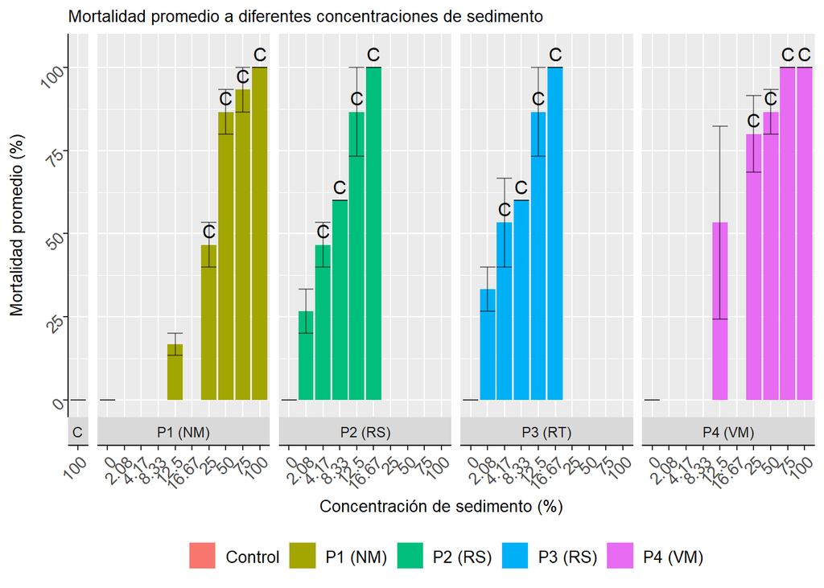

```r
p1<-ggplot(sed_mean, aes(x=factor(conc), y=promedio, fill=Punto))+
  geom_col(position=position_dodge())+
  theme(axis.line = element_line(colour = "black"))+
  geom_errorbar(aes(ymin=promedio-stderror, ymax=promedio+stderror),position=position_dodge(),alpha=0.5)+
  xlab("Concentración de sedimento (%)")+
  ylab("Mortalidad promedio (%)")+
  ggtitle("Mortalidad promedio a diferentes concentraciones de sedimento")+
  facet_grid(~Punto,scales = "free_x", space = "free_x",switch = "x",labeller=as_labeller(names))+
  scale_fill_discrete(name = "Punto", labels = c("Control", "P1 (NM)", "P2 (RS)","P3 (RS)","P4 (VM)"))+
#  scale_y_continuous(breaks = seq(0, 125, by = 25))+
#  ylim(0,120)+
  scale_y_continuous(limits = c(0, 105), breaks = c(0,25,50,75,100))+
  geom_text(aes(label=diff),size=4,hjust=0.5,vjust=-0.5,color="black")+
  theme(plot.title = element_text(size = 10))+
  theme(legend.title = element_text(size = 10))+
  theme(legend.text = element_text(size = 10))+
  theme(axis.title = element_text(size = 10))+
  theme(axis.text = element_text(size = 10,angle = 45,hjust=1))+
  theme(legend.position = "bottom")+
  theme(legend.title=element_blank())
p1
```

```r
ggsave("~/Laptop Drive/Toxicología Acuática/Tesis/Resultados/Figuras/Gráficas/mortalidad_sedimento_barras.png",width=1800,height=1200,units="px",dpi=200)
```

#### Pore water

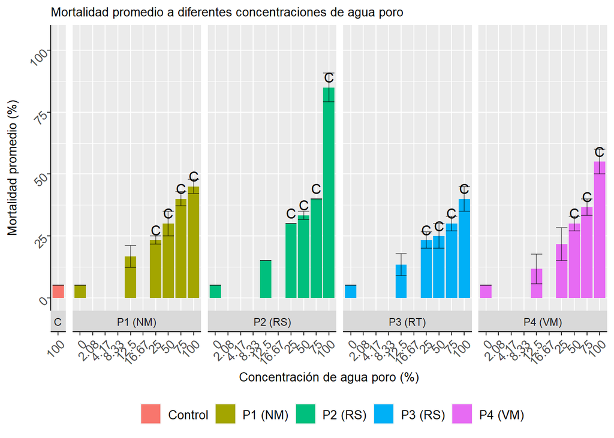

```r
p2<-ggplot(agua_mean, aes(x=factor(conc), y=promedio, fill=Punto))+
  geom_col(position=position_dodge())+
  theme(axis.line = element_line(colour = "black"))+
  geom_errorbar(aes(ymin=promedio-stderror, ymax=promedio+stderror),position=position_dodge(),alpha=0.5)+
  xlab("Concentración de agua poro (%)")+
  ylab("Mortalidad promedio (%)")+
  ggtitle("Mortalidad promedio a diferentes concentraciones de agua poro")+
  facet_grid(~Punto,scales = "free_x", space = "free_x",switch = "x",labeller=as_labeller(names))+
  scale_fill_discrete(name = "Punto", labels = c("Control", "P1 (NM)", "P2 (RS)","P3 (RS)","P4 (VM)"))+
#  scale_y_continuous(breaks = seq(0, 125, by = 25))+
#  ylim(0,120)+
  scale_y_continuous(limits = c(0, 105), breaks = c(0,25,50,75,100))+
  geom_text(aes(label=diff),size=4,hjust=0.5,vjust=-0.5,color="black")+
  theme(plot.title = element_text(size = 10))+
  theme(legend.title = element_text(size = 10))+
  theme(legend.text = element_text(size = 10))+
  theme(axis.title = element_text(size = 10))+
  theme(axis.text = element_text(size = 10,angle = 45,hjust=1))+
  theme(legend.position = "bottom")+
  theme(legend.title=element_blank())
p2
```

```r
ggsave("~/Laptop Drive/Toxicología Acuática/Tesis/Resultados/Figuras/Gráficas/mortalidad_aguaporo_barras.png",width=1800,height=1200,units="px",dpi=200)
```

### Line (not used)

#### Sediment

```
## `geom_line()`: Each group consists of only one observation.
## ℹ Do you need to adjust the group aesthetic?
```

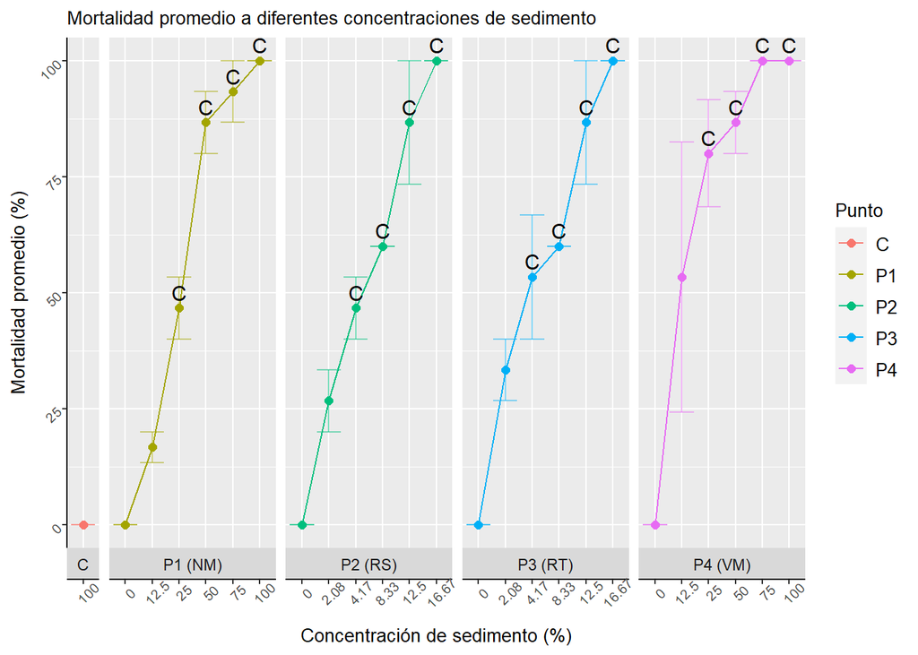

```r
p<-ggplot(sed_mean[!is.na(sed_mean$promedio),], aes(x=factor(conc), y=promedio, colour=Punto,group=Punto))+
  geom_point(size=2)+
  geom_line()+
  theme(axis.line = element_line(colour = "black"))+
  geom_errorbar(aes(ymin=promedio-stderror, ymax=promedio+stderror),position=position_dodge(),alpha=0.5)+
  xlab("Concentración de sedimento (%)")+
  ylab("Mortalidad promedio (%)")+
  ggtitle("Mortalidad promedio a diferentes concentraciones de sedimento")+
  facet_grid(~Punto,scales = "free_x", space = "free_x",switch = "x",labeller=as_labeller(names))+
  scale_fill_discrete(name = "Punto", labels = c("Control", "P1 (NM)", "P2 (RS)","P3 (RS)","P4 (VM)"))+
#  ylim(0,120)+
  scale_y_continuous(breaks = seq(0, 125, by = 25))+
#  ylim(0,120)+
  geom_text(aes(label=diff),size=4,hjust=0.5,vjust=-0.5,color="black")+
  theme(plot.title = element_text(size = 10))+
  theme(legend.title = element_text(size = 10))+
  theme(legend.text = element_text(size = 10))+
  theme(axis.title = element_text(size = 10))+
  theme(axis.text = element_text(size = 7.5,angle = 45))
p
```

#### Pore water

```
## `geom_line()`: Each group consists of only one observation.
## ℹ Do you need to adjust the group aesthetic?
```

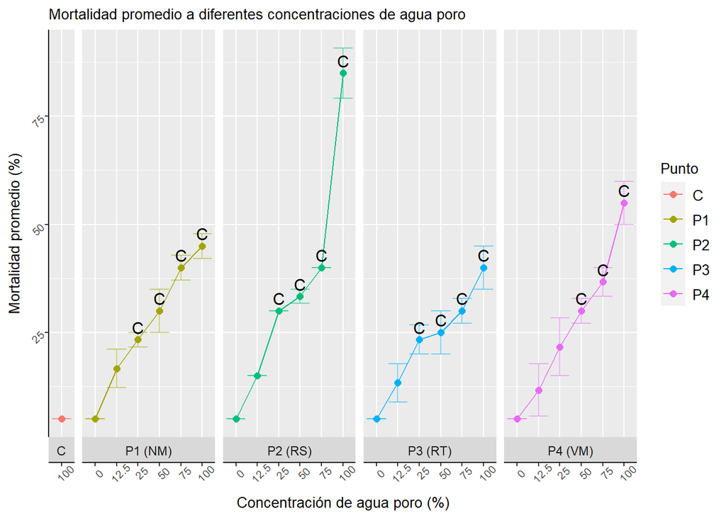

```r
p<-ggplot(agua_mean[!is.na(agua_mean$promedio),], aes(x=factor(conc), y=promedio, colour=Punto,group=Punto))+
  geom_point(size=2)+
  geom_line()+
  theme(axis.line = element_line(colour = "black"))+
  geom_errorbar(aes(ymin=promedio-stderror, ymax=promedio+stderror),position=position_dodge(),alpha=0.5)+
  xlab("Concentración de agua poro (%)")+
  ylab("Mortalidad promedio (%)")+
  ggtitle("Mortalidad promedio a diferentes concentraciones de agua poro")+
  facet_grid(~Punto,scales = "free_x", space = "free_x",switch = "x",labeller=as_labeller(names))+
  scale_fill_discrete(name = "Punto", labels = c("Control", "P1 (NM)", "P2 (RS)","P3 (RS)","P4 (VM)"))+
#  ylim(0,120)+
  scale_y_continuous(breaks = seq(0, 125, by = 25))+
#  ylim(0,120)+
  geom_text(aes(label=diff),size=4,hjust=0.5,vjust=-0.5,color="black")+
  theme(plot.title = element_text(size = 10))+
  theme(legend.title = element_text(size = 10))+
  theme(legend.text = element_text(size = 10))+
  theme(axis.title = element_text(size = 10))+
  theme(axis.text = element_text(size = 7.5,angle = 45))
p
```

## GMS

### Reshaping data

```r
gmisedimento<- read_excel("~/Laptop Drive/Toxicología Acuática/Tesis/Resultados/Teratogénesis_R.xlsx", shee="GMI Sedimento", range="A1:F301")
gmiaguaporo<- read_excel("~/Laptop Drive/Toxicología Acuática/Tesis/Resultados/Teratogénesis_R.xlsx", shee="GMI Agua poro", range="A1:F301")

gmised_pivot<-pivot_longer(gmisedimento,!Punto,names_to = "Hora",values_to="GMI") %>% cbind(Matriz="Sedimento")
gmised_mean<-gmised_pivot %>% group_by(Punto,Hora) %>%
  summarize(promedio=mean(GMI, na.rm=TRUE),stderror=std.error(GMI, na.rm=TRUE)) %>%
  cbind(Matriz="Sedimento")
gmiagua_pivot<-pivot_longer(gmiaguaporo,!Punto,names_to = "Hora",values_to="GMI") %>% cbind(Matriz="Agua poro")
gmiagua_mean<-gmiagua_pivot %>% group_by(Punto,Hora) %>%
  summarize(promedio=mean(GMI, na.rm=TRUE),stderror=std.error(GMI, na.rm=TRUE)) %>%
  cbind(Matriz="Agua poro")
gmi_sed_agua_pivot<-rbind(gmised_pivot,gmiagua_pivot)
gmi_sed_agua_mean<-rbind(gmised_mean,gmiagua_mean)
```

### Labeling significant differences

```r
#esto se usará en GMS
gms_sed_agua<-read_excel("~/Laptop Drive/Toxicología Acuática/Tesis/Resultados/p values.xlsx",sheet="gms_sed_agua")
gms_sed<-read_excel("~/Laptop Drive/Toxicología Acuática/Tesis/Resultados/p values.xlsx", sheet = "gms_sed",
    range = "A1:C26")
gms_agua<-read_excel("~/Laptop Drive/Toxicología Acuática/Tesis/Resultados/p values.xlsx", sheet = "gms_agua",
    range = "A1:C26")
gmi_sed_agua_mean$diff<-gms_sed_agua$diff
gmised_mean$diff<-gms_sed$diff
gmiagua_mean$diff<-gms_agua$diff
```

### Line

#### Both

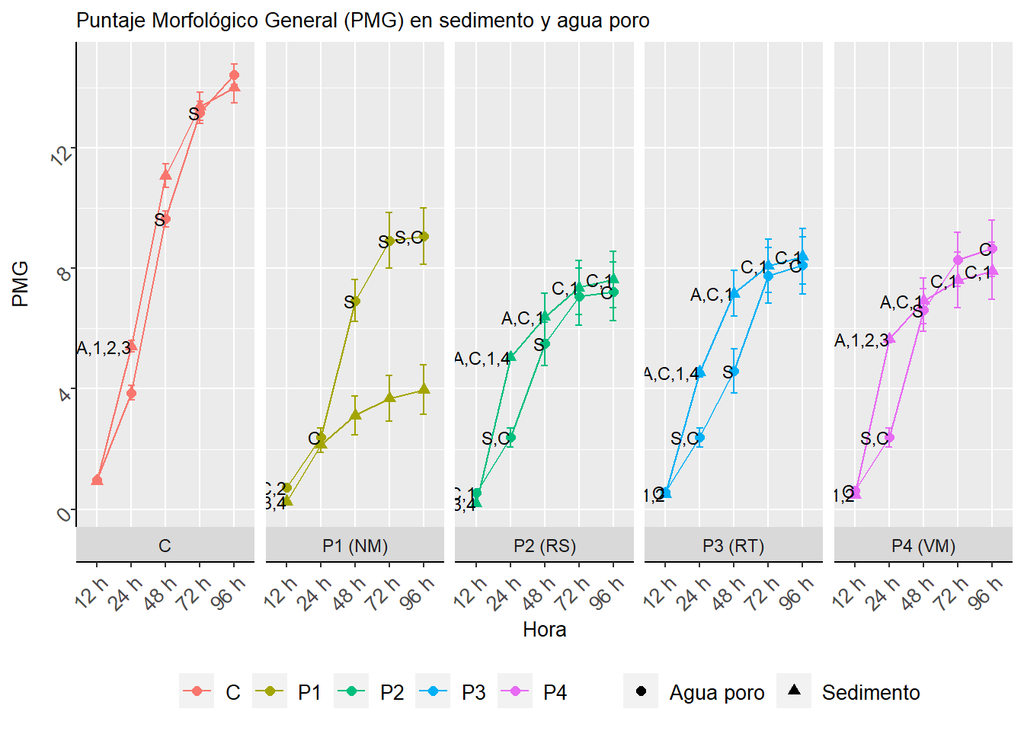

```r
p<-ggplot(gmi_sed_agua_mean, aes(x = as.factor(Hora), y = promedio, colour=Punto, group=Matriz,shape=Matriz))+
  geom_point(size=2)+
  geom_line()+
  geom_errorbar(aes(ymin=promedio-stderror, ymax=promedio+stderror),alpha=1,width=0.2)+
  xlab("Hora")+
  ylab("PMG")+
  ggtitle("Puntaje Morfológico General (PMG) en sedimento y agua poro")+
  theme(axis.line = element_line(colour = "black"))+
  facet_grid(~Punto,scales = "free_x", space = "free_x",switch = "x",labeller=as_labeller(names))+
  scale_fill_discrete(name = "Punto", labels = c("Control", "P1 (NM)", "P2 (RS)","P3 (RT)","P4 (VM)"))+
#  ylim(0,20)+
  scale_y_continuous(breaks = seq(0,20, by=4))+
#  ylim(0,20)+
  geom_text(aes(label=diff),size=3,hjust=1,color="black")+
  theme(plot.title = element_text(size = 10))+
  theme(legend.title = element_text(size = 10))+
  theme(legend.text = element_text(size = 10))+
  theme(axis.title = element_text(size = 10))+
  theme(axis.text = element_text(size = 10,angle=45,hjust=1))+
  theme(legend.position = "bottom")+
  theme(legend.title = element_blank())
p
```

```r
#ggsave("~/Laptop Drive/Toxicología Acuática/Tesis/Resultados/Figuras/Gráficas/pmg_sedimento_aguaporo.png",width=1800,height=1200,units="px",dpi=200)
```

#### Sediment

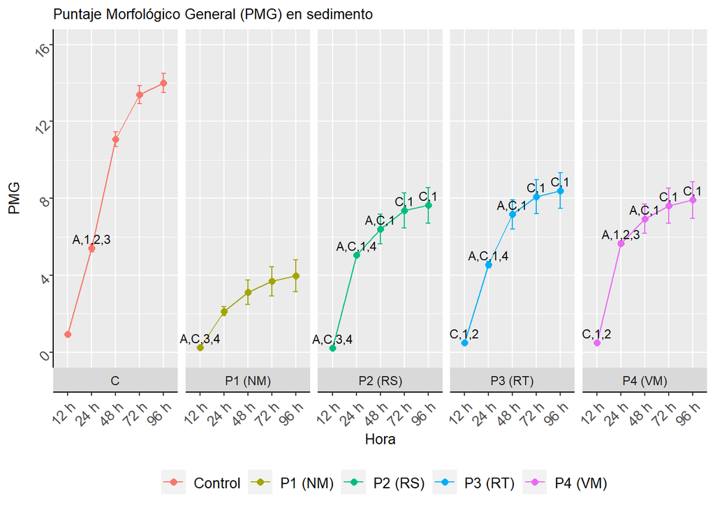

```r
p3<-ggplot(gmised_mean, aes(x = as.factor(Hora), y = promedio, colour=Punto, group=Matriz))+
  geom_point(size=2)+
  geom_line()+
  geom_errorbar(aes(ymin=promedio-stderror, ymax=promedio+stderror),alpha=1,width=0.2)+
  xlab("Hora")+
  ylab("PMG")+
  ggtitle("Puntaje Morfológico General (PMG) en sedimento")+
  theme(axis.line = element_line(colour = "black"))+
  facet_grid(~Punto,scales = "free_x", space = "free_x",switch = "x",labeller=as_labeller(names))+
  scale_colour_discrete(name = "Punto", labels = c("Control", "P1 (NM)", "P2 (RS)","P3 (RT)","P4 (VM)"))+
#  ylim(0,16)+
#  scale_y_continuous(breaks = seq(0,16, by=4))+
  scale_y_continuous(limits = c(0, 16), breaks = c(0,4,8,12,16))+
  geom_text(aes(label=diff),size=3,hjust=0.5,vjust=-0.5,color="black")+
  coord_cartesian(clip='off')+
  theme(plot.title = element_text(size = 10))+
  theme(legend.title = element_text(size = 10))+
  theme(legend.text = element_text(size = 10))+
  theme(axis.title = element_text(size = 10))+
  theme(axis.text = element_text(size = 10,angle=45,hjust=1))+
  theme(legend.position = "bottom")+
  theme(legend.title = element_blank())
p3
```

```r
#ggsave("~/Laptop Drive/Toxicología Acuática/Tesis/Resultados/Figuras/Gráficas/pmg_sedimento.png",width=1800,height=1200,units="px",dpi=200)
```

#### Pore water

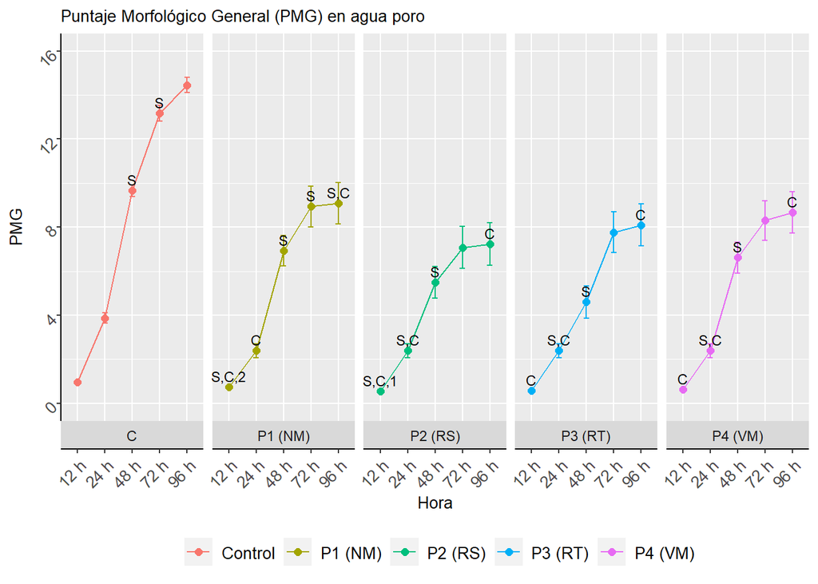

```r
p4<-ggplot(gmiagua_mean, aes(x = as.factor(Hora), y = promedio, colour=Punto, group=Matriz))+
  geom_point(size=2)+
  geom_line()+
  geom_errorbar(aes(ymin=promedio-stderror, ymax=promedio+stderror),alpha=1,width=0.2)+
  xlab("Hora")+
  ylab("PMG")+
  ggtitle("Puntaje Morfológico General (PMG) en agua poro")+
  theme(axis.line = element_line(colour = "black"))+
  facet_grid(~Punto,scales = "free_x", space = "free_x",switch = "x",labeller=as_labeller(names))+
  scale_colour_discrete(name = "Punto", labels = c("Control", "P1 (NM)", "P2 (RS)","P3 (RT)","P4 (VM)"))+
#  ylim(0,16)+
#  scale_y_continuous(breaks = seq(0,16, by=4))+
  scale_y_continuous(limits = c(0, 16), breaks = c(0,4,8,12,16))+
  geom_text(aes(label=diff),size=3,hjust=0.5,vjust=-0.5,color="black")+
  coord_cartesian(clip='off')+
  theme(plot.title = element_text(size = 10))+
  theme(legend.title = element_text(size = 10))+
  theme(legend.text = element_text(size = 10))+
  theme(axis.title = element_text(size = 10))+
  theme(axis.text = element_text(size = 10,angle=45,hjust=1))+
  theme(legend.position = "bottom")+
  theme(legend.title = element_blank())
p4
```

```r
#ggsave("~/Laptop Drive/Toxicología Acuática/Tesis/Resultados/Figuras/Gráficas/pmg_aguaporo.png",width=1800,height=1200,units="px",dpi=200)
```

Joining

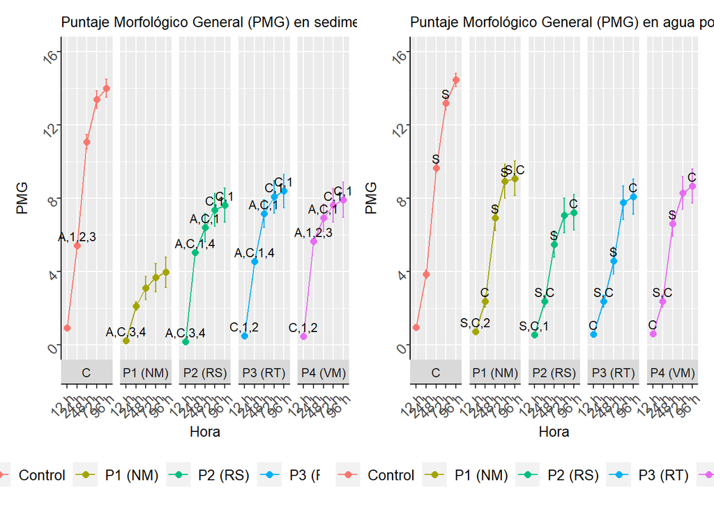

```r
library(patchwork)
p3+p4
```

```r
ggsave("~/Laptop Drive/Toxicología Acuática/Tesis/Resultados/Figuras/Gráficas/pmg_sedimento_y_agua_poro.png",width=4200,height=2400,units="px",dpi=350)
```

# Run All

```r
#Use this chunk to run all ones above
```